# Group Project 2

2024-11-07

# Introduction

In this document, we are using the Hotel Booking Cancellation Prediction dataset, a comprehensive collection of data aimed at predicting hotel booking cancellations, to try and maximize the hotel’s profit by being able to overbook the hotel. The data is originally from the article “Hotel Booking Demand Datasets”, written by Nuno Antonio, Ana Almeida, and Luis Nunes for Data in Brief, Volume 22, February 2019.

### Business Problem

The given hotel has a cancellation rate of 32.77% and therefore can not utilize it’s full capacity, thus not working at maximum profitability. Losing out on a significant amount of profit means disadvantages for the business, leading to decreased competitiveness, ultimately putting the business at risk of being unable to compete. **The question to answer is if a customer, identified by information collectable in advance, will or will not cancel their booking.**

### Business Solution

We are going to go through the process of building supervised machine learning models to facilitate the predictions.

## Step 1: Clean Data

```r
#Load Libraries
# Load libraries
library(ggplot2)
library(dplyr)
library(corrplot)
#Load CSV
book = read.csv("booking.csv")

#Delete Booking_ID since it doesn't influence the prediction
book$Booking_ID = NULL

#TODO: convert date.of.reservation into a usable variable

#factorize character variables
book$type.of.meal = as.factor(book$type.of.meal)
book$room.type = as.factor(book$room.type)
book$market.segment.type = as.factor(book$market.segment.type)

#make y-variable binary
book$booking.status = ifelse(book$booking.status=="Canceled",1,0)

summary(book)
```

```
##  number.of.adults number.of.children number.of.weekend.nights
##  Min.   :0.000    Min.   : 0.0000    Min.   :0.0000
##  1st Qu.:2.000    1st Qu.: 0.0000    1st Qu.:0.0000
##  Median :2.000    Median : 0.0000    Median :1.0000
##  Mean   :1.845    Mean   : 0.1054    Mean   :0.8107
##  3rd Qu.:2.000    3rd Qu.: 0.0000    3rd Qu.:2.0000
##  Max.   :4.000    Max.   :10.0000    Max.   :7.0000
##
##  number.of.week.nights       type.of.meal   car.parking.space
##  Min.   : 0.000        Meal Plan 1 :27842   Min.   :0.00000
##  1st Qu.: 1.000        Meal Plan 2 : 3306   1st Qu.:0.00000
##  Median : 2.000        Meal Plan 3 :    5   Median :0.00000
##  Mean   : 2.205        Not Selected: 5132   Mean   :0.03098
##  3rd Qu.: 3.000                             3rd Qu.:0.00000
##  Max.   :17.000                             Max.   :1.00000
##
##        room.type       lead.time         market.segment.type    repeated
##  Room_Type 1:28138   Min.   :  0.00   Aviation     :  125    Min.   :0.00000
##  Room_Type 2:  692   1st Qu.: 17.00   Complementary:  391    1st Qu.:0.00000
##  Room_Type 3:    7   Median : 57.00   Corporate    : 2017    Median :0.00000
##  Room_Type 4: 6059   Mean   : 85.24   Offline      :10531    Mean   :0.02563
##  Room_Type 5:  265   3rd Qu.:126.00   Online       :23221    3rd Qu.:0.00000
##  Room_Type 6:  966   Max.   :443.00                          Max.   :1.00000
##  Room_Type 7:  158
##       P.C              P.not.C        average.price    special.requests
##  Min.   : 0.00000   Min.   : 0.0000   Min.   :  0.00   Min.   :0.0000
##  1st Qu.: 0.00000   1st Qu.: 0.0000   1st Qu.: 80.30   1st Qu.:0.0000
##  Median : 0.00000   Median : 0.0000   Median : 99.45   Median :0.0000
##  Mean   : 0.02334   Mean   : 0.1534   Mean   :103.42   Mean   :0.6197
##  3rd Qu.: 0.00000   3rd Qu.: 0.0000   3rd Qu.:120.00   3rd Qu.:1.0000
##  Max.   :13.00000   Max.   :58.0000   Max.   :540.00   Max.   :5.0000
##
##  date.of.reservation booking.status
##  Length:36285        Min.   :0.0000
##  Class :character    1st Qu.:0.0000
##  Mode  :character    Median :0.0000
##                      Mean   :0.3277
##                      3rd Qu.:1.0000
##                      Max.   :1.0000
##
```

### Step 2: Visualize the data

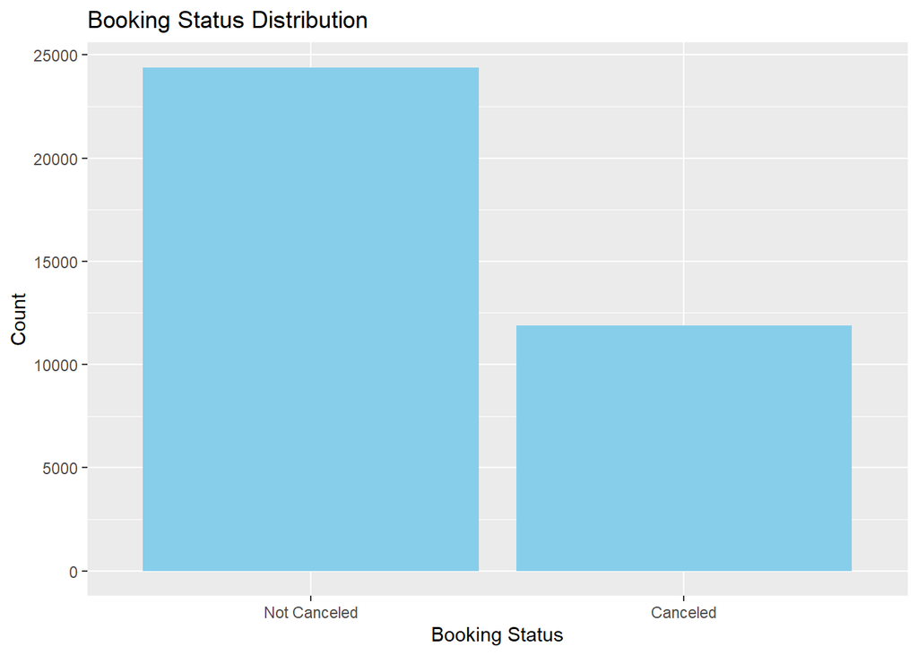

```r
# Check cancellation distribution
ggplot(book, aes(x = factor(booking.status, labels = c("Not Canceled", "Canceled")))) +
  geom_bar(fill = "skyblue") +
  labs(title = "Booking Status Distribution", x = "Booking Status", y = "Count")
```

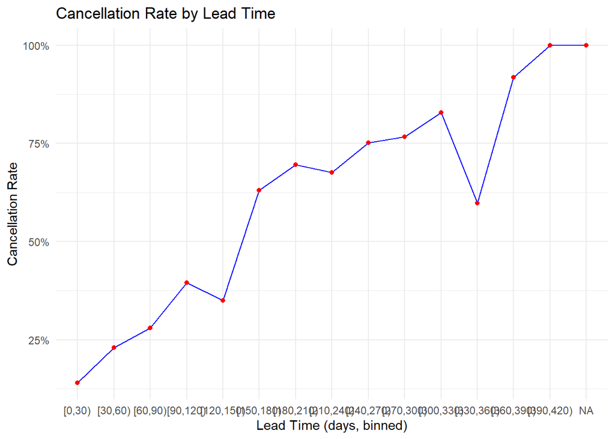

```r
# Group data by lead time intervals and calculate the cancellation rate
# Creating lead time intervals (bins) for a smoother visualization
book$lead_time_bin <- cut(book$lead.time, breaks = seq(0, max(book$lead.time, na.rm = TRUE), by = 30), right = FALSE)

# Calculate cancellation rate for each lead time bin
lead_time_cancellation <- book %>%
  group_by(lead_time_bin) %>%
  summarize(cancellation_rate = mean(booking.status), n = n())

# Plot cancellation rate by lead time bin
ggplot(lead_time_cancellation, aes(x = lead_time_bin, y = cancellation_rate)) +
  geom_line(group = 1, color = "blue") +
  geom_point(color = "red") +
  labs(title = "Cancellation Rate by Lead Time",
       x = "Lead Time (days, binned)",
       y = "Cancellation Rate") +
  theme(axis.text.x = element_text(angle = 45, hjust = 1)) +
  scale_y_continuous(labels = scales::percent) +
  theme_minimal()
```

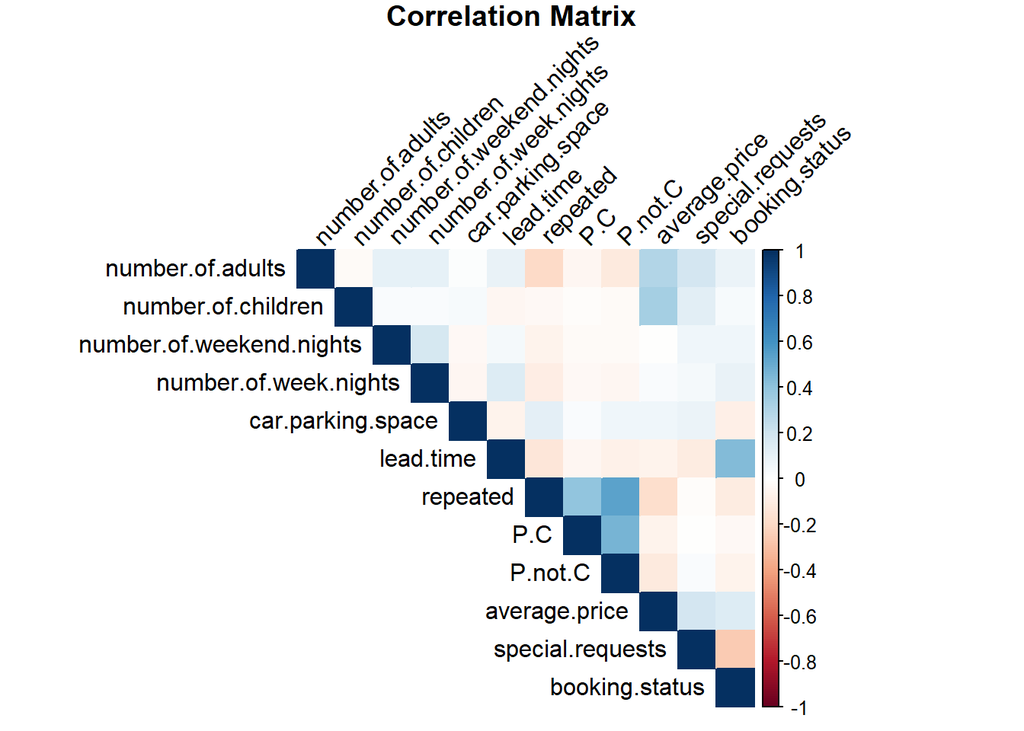

```r
# Explore correlation between numerical variables
# Remove non-numeric columns
book_numeric <- book %>% select(where(is.numeric))
# Calculate correlation matrix
corr_matrix <- cor(book_numeric, use = "complete.obs")
# Plot correlation matrix
corrplot(corr_matrix, method = "color", type = "upper", tl.col = "black", tl.srt = 45, title = "Correlation Matrix", mar = c(0, 0, 1, 0))
```